# M215 Lab 6

Shanpeng Li

```r
library(survival)
library(KMsurv)
```

### Handling Ties (Section 8.4)

We can also modify how `coxph` handles ties through the `ties` option. By default `R` implements Efron’s approximation, although the Breslow method is quite popular in other standard statistical software. Each method may yield subtle differences in the log-partial likelihood; which in turn affects the coefficient estimates, covariance matrix, and so on. Below is an example to compare such differences.

```r
# Example 8.4
data(kidney, package = "KMsurv")
head(kidney)
```

```
##   time delta type
## 1  1.5     1    1
## 2  3.5     1    1
## 3  4.5     1    1
## 4  4.5     1    1
## 5  5.5     1    1
## 6  8.5     1    1
```

```r
length(kidney$time[kidney$delta == 1])
```

```
## [1] 26
```

```r
length(unique(kidney$time[kidney$delta == 1]))
```

```
## [1] 16
```

```r
fit.efron   <- coxph(Surv(time, delta) ~ type, data = kidney)
fit.breslow <- coxph(Surv(time, delta) ~ type, data = kidney, ties = "breslow")
fit.exact   <- coxph(Surv(time, delta) ~ type, data = kidney, ties = "exact")

cbind(fit.efron$coefficients, fit.breslow$coefficients, fit.exact$coefficients)
```

```
##            [,1]       [,2]       [,3]
## type -0.6125714 -0.6181731 -0.6294443
```

As we can see, all three methods are quite similar in the presence of ties. When there are no ties, all three methods would yield the same result.

## Hypothesis Testing (Section 8.5)

We will use the `larynx` dataset.

```r
#Example 8.2
data(larynx, package = "KMsurv")
head(larynx)
```

```
##   stage time age diagyr delta
## 1     1  0.6  77     76     1
## 2     1  1.3  53     71     1
## 3     1  2.4  45     71     1
## 4     1  2.5  57     78     0
## 5     1  3.2  58     74     1
## 6     1  3.2  51     77     0
```

```r
#Create dummy variables for stage variable (s2, s3, s4)
larynx$s2 <- ifelse(larynx$stage == 2, 1, 0)
larynx$s3 <- ifelse(larynx$stage == 3, 1, 0)
larynx$s4 <- ifelse(larynx$stage == 4, 1, 0)

#Only looking stage
fit.larynx <- coxph(Surv(time, delta) ~ factor(stage) ,
                    data = larynx, ties = 'breslow')

fit.larynx
```

```
## Call:
## coxph(formula = Surv(time, delta) ~ factor(stage), data = larynx,
##     ties = "breslow")
##
##                   coef exp(coef) se(coef)     z        p
## factor(stage)2 0.06576   1.06797  0.45844 0.143   0.8859
## factor(stage)3 0.61206   1.84423  0.35520 1.723   0.0849
## factor(stage)4 1.72284   5.60040  0.41966 4.105 4.04e-05
##
## Likelihood ratio test=16.26  on 3 df, p=0.001001
## n= 90, number of events= 50
```

```r
#Adding age to the stages.
fit.larynx2 <- coxph(Surv(time, delta) ~ factor(stage) + age,
                     data = larynx, ties = 'breslow')

fit.larynx2
```

```
## Call:
## coxph(formula = Surv(time, delta) ~ factor(stage) + age, data = larynx,
##     ties = "breslow")
##
##                   coef exp(coef) se(coef)     z        p
## factor(stage)2 0.13856   1.14862  0.46231 0.300    0.764
## factor(stage)3 0.63835   1.89335  0.35608 1.793    0.073
## factor(stage)4 1.69306   5.43607  0.42221 4.010 6.07e-05
## age            0.01890   1.01908  0.01425 1.326    0.185
##
## Likelihood ratio test=18.07  on 4 df, p=0.001197
## n= 90, number of events= 50
```

### Score, Likelihood Ratio, and Wald Tests

Continuing with the `larynx` example, suppose we are interested in testing the hypothesis $H_0: \beta_1 = \beta_2 = \beta_3 = 0$. Therefore, we are testing no difference in survival between the different stages. We will show now how to implement the score, likelihood ratio, and Wald tests manually through R for this hypothesis.

Performing the score test is rather involved. We would need to calculate the estimate of $\beta_4$ under the null hypothesis.

```r
#Example 8.2 (pg. 264)

#Score Test
fit.age  <- coxph(Surv(time, delta) ~ age, data = larynx, ties = 'breslow')
age.coef <- fit.age$coefficients
```

We now need to fit our model using the ‘null’ estimates and extract the score statistic.

```r
fit.new <- update(fit.larynx2, iter.max = 0, init = c(0, 0, 0, age.coef)) #Updates model with NEW initial values.

X2.sc <- fit.new$score
round(cbind(X2.sc, 1 - pchisq(X2.sc, 3)), 4)
```

```
##        X2.sc
## [1,] 20.5766 1e-04
```

For the likelihood ratio tests, we can extract the two log-partial likelihoods using `$loglik[2]`. Note that the second element in `loglik` corresponds to the log-partial likelihood of the fitted model, while the first element is the log-partial likelihood of the null model.

```r
#Likelihood Ratio Test
X2.lrt <- 2 * (fit.larynx2$loglik[2] - fit.age$loglik[2])
round(cbind(X2.lrt, 1-pchisq(X2.lrt, 3)), 4)
```

```
##       X2.lrt
## [1,] 15.4529 0.0015
```

The Wald is also very easy to implement. We can get the variance-covariance matrix through `$var`. For good practice we define `b.null`, where
$$H_0: \beta = b.null$$
. In our example, $b.null = (0, 0, 0)$.

```r
#Wald Test
b.null <- c(0, 0, 0)
X2.wald <- t(fit.larynx2$coefficients[1:3] - b.null) %*%
  solve(fit.larynx2$var[-4, -4]) %*%
  (fit.larynx2$coefficients[1:3] - b.null)
round(cbind(X2.wald, 1-pchisq(X2.wald, 3)), 4)
```

```
##         [,1]  [,2]
## [1,] 17.6288 5e-04
```

### General Tests Using Wald

The Wald test is actually more flexible. We can define a contrast $C$ to test the null, $H_0: C\beta = C\beta_0$. The Wald test can be writte as:
$$(Cb - C\beta_0)'[C\Sigma C']^{-1}(Cb-C\beta_0) \sim \chi^2(q),$$
where $q$ is the row rank of $C$ and $q \leq p$.

Testing $H_0: \beta_1 = 0$

```r
#Testing b1 = 0
C  <- c(1, 0, 0, 0)
b0 <- c(0, 0, 0, 0)
b  <- fit.larynx2$coefficients
V  <- fit.larynx2$var
t(C %*% b - C %*% b0) %*% solve(t(C) %*% V %*% C) %*%
  (C %*% b - C %*% b0)
```

```
##            [,1]
## [1,] 0.08983425
```

```r
fit.larynx2
```

```
## Call:
## coxph(formula = Surv(time, delta) ~ factor(stage) + age, data = larynx,
##     ties = "breslow")
##
##                   coef exp(coef) se(coef)     z        p
## factor(stage)2 0.13856   1.14862  0.46231 0.300    0.764
## factor(stage)3 0.63835   1.89335  0.35608 1.793    0.073
## factor(stage)4 1.69306   5.43607  0.42221 4.010 6.07e-05
## age            0.01890   1.01908  0.01425 1.326    0.185
##
## Likelihood ratio test=18.07  on 4 df, p=0.001197
## n= 90, number of events= 50
```

Testing $H_0: \beta_1 = \beta_2 = \beta_3$.

```r
#Testing b1 = b2 = b3
C  <- rbind(c(1, -1, 0, 0), c(0, -1, 1, 0))
b0 <- c(0, 0, 0, 0)
t(C %*% b - C %*% b0) %*% solve(C %*% V %*% t(C)) %*%
  (C %*% b - C %*% b0)
```

```
##          [,1]
## [1,] 10.73245
```

## Baseline Hazard and Estimation of Survival Function (Section 8.8)

Recall the Cox PH model formulation,
$$h(t|\mathbf{x}) = h_{0}(t) \exp(\mathbf{x}^T\boldsymbol{\beta}).$$
After we estimate $\beta$, it may be of interest to calculate survival probabilities for a new subject. To do so, we would need an estimate of $h_0(t)$, or rather $H_0(t)$. Breslow’s estimator of the baseline cumulative hazard, $\hat{H}_0(t)$ is generally used and can be easily implemented in `R` through `basehaz`. Setting `centered = F` allows us to estimate the cumulative hazard when $\mathbf{x_i} = 0$. Hence provided that the all covariate values are 0,
$$\hat{S}_0(t) = \exp[-\hat{H}_0(t)].$$
Below is an example using the `larynx` dataset where our covariates are the stages of disease and age at diagnosis.

```r
b.haz <- basehaz(fit.larynx2, centered = F)
t     <- b.haz[ ,2]
S.est <- cbind(exp(-b.haz[,1]), t)
```

Suppose now that we are interested in estimate the survival probability given a set of covariates, $\mathbf{x_0}$. Then,
$$\hat{S}(t|\mathbf{x_0}) = \hat{S}_0(t)^{\exp(\mathbf{x_0}^T\hat{\beta})}.$$
To continue with our example, let us look at the estimated survival probabilities of a patient that is age 60 at diagnosis for each stage. This can be easily implemented in `R`.

```r
b.est <- fit.larynx2$coefficients

S1 <- S.est[,1]^(exp(t(b.est) %*% c(0, 0, 0, 60)))
S2 <- S.est[,1]^(exp(t(b.est) %*% c(1, 0, 0, 60)))
S3 <- S.est[,1]^(exp(t(b.est) %*% c(0, 1, 0, 60)))
S4 <- S.est[,1]^(exp(t(b.est)%*% c(0, 0, 1, 60)))
```

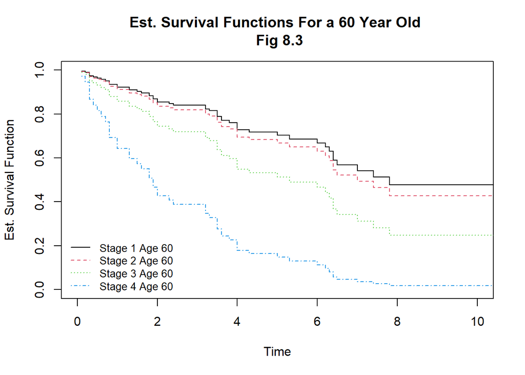

```r
plot(S1 ~ t, type = 's', xlim = c(0, 10), ylim = c(0, 1),
     main = 'Est. Survival Functions For a 60 Year Old \n Fig 8.3',
     ylab = 'Est. Survival Function', xlab = 'Time')
lines(S2 ~ t, type = 's', lty = 2, col = 2)
lines(S3 ~ t, type = 's', lty = 3, col = 3)
lines(S4 ~ t, type = 's', lty = 4, col = 4)
legend('bottomleft',
       c('Stage 1 Age 60', 'Stage 2 Age 60', 'Stage 3 Age 60', 'Stage 4 Age 60'),
       col = 1:4, lty = 1:4, bty = 'n', cex = .85)
```

If we are interested in estimating the 5-year survival probability, we can easily do so.

```r
res <- cbind(S1[max(which(t <= 5))], S2[max(which(t <= 5))],
             S3[max(which(t <= 5))], S4[max(which(t <= 5))])
rownames(res) <- c('Est. Surv.')
colnames(res) <- c('Stage 1', 'Stage 2', 'Stage 3', 'Stage 4')
round(res, 3)
```

```
##            Stage 1 Stage 2 Stage 3 Stage 4
## Est. Surv.   0.703   0.667   0.513   0.147
```

Sometimes, we are interested in calculating a confidence interval for the estimated survival probability. Fortunately, under certain regularity conditions, the estimated survival probability is asymptotically normal. However, the variance is not easy to find. Luckily, `survival` has a nice feature that allows us to extract the estimate, standard error, and confidence interval for each observed event time given a set of covariates using the `survfit` command and a fitted Cox model through `coxph`. The set of covariates must be in the form of a data frame with variable names equal to those in the model. Different transformations, and confidence levels can be specified.

```r
fit.s1 <- survfit(fit.larynx2, newdata = data.frame(stage = 1, age = 60),
                  se.fit = TRUE, conf.int = .95, conf.type = 'log-log')

summary(fit.s1)
```

```
## Call: survfit(formula = fit.larynx2, newdata = data.frame(stage = 1,
##     age = 60), se.fit = TRUE, conf.int = 0.95, conf.type = "log-log")
##
##  time n.risk n.event survival std.err lower 95% CI upper 95% CI
##   0.1     90       1    0.995 0.00526        0.962        0.999
##   0.2     89       1    0.990 0.00780        0.955        0.998
##   0.3     88       3    0.974 0.01353        0.929        0.991
##   0.4     85       1    0.969 0.01533        0.919        0.988
##   0.5     84       1    0.963 0.01712        0.909        0.985
##   0.6     83       1    0.957 0.01885        0.900        0.982
##   0.7     82       1    0.952 0.02055        0.890        0.979
##   0.8     81       3    0.935 0.02541        0.862        0.970
##   1.0     78       2    0.922 0.02877        0.842        0.963
##   1.3     76       2    0.909 0.03211        0.821        0.955
##   1.5     74       1    0.903 0.03377        0.811        0.951
##   1.6     73       1    0.896 0.03545        0.801        0.947
##   1.8     72       2    0.883 0.03875        0.780        0.939
##   1.9     70       2    0.869 0.04197        0.759        0.931
##   2.0     68       2    0.855 0.04514        0.739        0.922
##   2.3     65       1    0.848 0.04678        0.728        0.918
##   2.4     64       1    0.840 0.04845        0.717        0.913
##   3.2     60       2    0.823 0.05196        0.693        0.902
##   3.3     57       1    0.815 0.05375        0.680        0.897
##   3.5     54       3    0.789 0.05907        0.644        0.880
##   3.6     51       2    0.771 0.06254        0.619        0.869
##   3.8     47       1    0.761 0.06439        0.606        0.862
##   4.0     46       3    0.729 0.06962        0.564        0.839
##   4.3     43       1    0.718 0.07132        0.551        0.831
##   5.0     34       1    0.703 0.07371        0.532        0.821
##   5.3     30       1    0.687 0.07632        0.511        0.810
##   6.0     26       1    0.669 0.07939        0.488        0.798
##   6.2     24       1    0.650 0.08261        0.464        0.785
##   6.3     22       1    0.630 0.08581        0.439        0.771
##   6.4     21       2    0.589 0.09135        0.391        0.743
##   6.5     19       1    0.568 0.09400        0.366        0.727
##   7.0     15       1    0.541 0.09769        0.335        0.708
##   7.4     13       1    0.513 0.10137        0.303        0.688
##   7.8      9       1    0.478 0.10664        0.263        0.665
```

```r
fit.s2 <- survfit(fit.larynx2, data.frame(stage = 2, age = 60),
                  se.fit = TRUE, conf.int = .95, conf.type = 'log-log')

summary(fit.s2)
```

```
## Call: survfit(formula = fit.larynx2, newdata = data.frame(stage = 2,
##     age = 60), se.fit = TRUE, conf.int = 0.95, conf.type = "log-log")
##
##  time n.risk n.event survival std.err lower 95% CI upper 95% CI
##   0.1     90       1    0.994 0.00620        0.954        0.999
##   0.2     89       1    0.988 0.00937        0.945        0.998
##   0.3     88       3    0.970 0.01704        0.910        0.990
##   0.4     85       1    0.964 0.01952        0.897        0.988
##   0.5     84       1    0.958 0.02202        0.885        0.985
##   0.6     83       1    0.951 0.02446        0.872        0.982
##   0.7     82       1    0.945 0.02686        0.859        0.979
##   0.8     81       3    0.925 0.03382        0.823        0.970
##   1.0     78       2    0.911 0.03870        0.796        0.963
##   1.3     76       2    0.897 0.04354        0.770        0.955
##   1.5     74       1    0.889 0.04592        0.757        0.952
##   1.6     73       1    0.882 0.04835        0.744        0.948
##   1.8     72       2    0.866 0.05311        0.718        0.940
##   1.9     70       2    0.851 0.05782        0.692        0.932
##   2.0     68       2    0.836 0.06246        0.666        0.924
##   2.3     65       1    0.827 0.06492        0.653        0.919
##   2.4     64       1    0.819 0.06743        0.639        0.915
##   3.2     60       2    0.800 0.07277        0.609        0.904
##   3.3     57       1    0.790 0.07541        0.594        0.899
##   3.5     54       3    0.762 0.08319        0.550        0.883
##   3.6     51       2    0.742 0.08817        0.521        0.872
##   3.8     47       1    0.731 0.09097        0.505        0.866
##   4.0     46       3    0.695 0.09939        0.456        0.845
##   4.3     43       1    0.683 0.10217        0.439        0.838
##   5.0     34       1    0.667 0.10594        0.418        0.829
##   5.3     30       1    0.649 0.11025        0.393        0.819
##   6.0     26       1    0.630 0.11467        0.368        0.808
##   6.2     24       1    0.609 0.11894        0.342        0.795
##   6.3     22       1    0.588 0.12335        0.316        0.783
##   6.4     21       2    0.545 0.13109        0.267        0.756
##   6.5     19       1    0.522 0.13453        0.243        0.741
##   7.0     15       1    0.494 0.13810        0.216        0.723
##   7.4     13       1    0.464 0.14167        0.188        0.703
##   7.8      9       1    0.428 0.14672        0.154        0.681
```